# Color Analysis of Floral Tissues

K. Uckele

2026-03-06

# 1 Introduction

This analysis explores the color properties of different floral tissues — bract, petal, and labellum — using spectral data sourced from Google Sheets. The analysis includes data loading, quality control, spectral processing, visualization, and the computation of summary descriptors.

# 2 Setup

## 2.1 Load Required Libraries

```r
## libraries
library(googlesheets4)
library(cowplot)
library(dplyr)
library(tibble)
library(knitr)
library(rmarkdown)
library(pavo)
```

## 2.2 Set working directory

```r
# Set the root directory to the project root
knitr::opts_knit$set(root.dir = normalizePath("../"))
```

## 2.3 Define Custom Operators

```r
# Define a 'not in' operator
`%notin%` = Negate(`%in%`)
```

## 2.4 Authenticate Google Sheets Access

Authenticate access to Google Sheets using your email. Ensure that the email has the necessary permissions to access the sheets.

```r
# Authenticate with Google Sheets
gs4_auth(email = "kuckele@ucsc.edu")
```

# 3 Quality Control

## 3.1 Load Spectral Data from Google Sheets

We load the spectral data for bract, petal, and labellum from the specified Google Sheets.

```r
# Specify the Google Sheets ID
sheet_id <- "12NWtlqKbLPAxU-rVBTqMQjY_6jH1DulVvNHS_QXAvFI"

# Load data for different floral tissues
bract <- read_sheet(ss = sheet_id, sheet = "Bract")
```

```
## Auto-refreshing stale OAuth token.
```

```
## ✔ Reading from "Color_reflectance_measurements".
```

```
## ✔ Range ''Bract''.
```

```r
petal <- read_sheet(ss = sheet_id, sheet = "Petal")
```

```
## ✔ Reading from "Color_reflectance_measurements".
```

```
## ✔ Range ''Petal''.
```

```r
labellum <- read_sheet(ss = sheet_id, sheet = "Labellum")
```

```
## ✔ Reading from "Color_reflectance_measurements".
```

```
## ✔ Range ''Labellum''.
```

# 4 Full Spectrum Analyses

## 4.1 Spectral Data Processing

## 4.2 Convert Data to rspec Objects

The spectral data is converted into rspec objects using the pavo package for further analysis.

```r
# Set seed for reproducibility
set.seed(1612217)

# Convert datasets to rspec objects with wavelength limits
bract_spec <- as.rspec(bract, lim = c(300, 700), whichwl = 1)
```

```
## The spectral data contain 555 negative value(s),
##  which may produce unexpected results if used in models.
## Consider using procspec() to correct them.
```

```r
petal_spec <- as.rspec(petal, lim = c(300, 700), whichwl = 1)
```

```
## The spectral data contain 272 negative value(s),
##  which may produce unexpected results if used in models.
## Consider using procspec() to correct them.
```

```r
labellum_spec <- as.rspec(labellum, lim = c(300, 700), whichwl = 1)

# change column names
colnames(bract_spec) <- gsub("-", "x", colnames(bract_spec))
colnames(petal_spec) <- gsub("-", "x", colnames(petal_spec))
colnames(labellum_spec) <- gsub("-", "x", colnames(labellum_spec))
```

Note: The conversion may produce warnings about negative values in spectral data, which are addressed in subsequent steps.

## 4.3 Average the Spectra

Aggregate the spectral data by sample names, averaging replicates.

```r
# Extract sample names by removing trailing numbers in parentheses
bract_samples <- gsub("\\([0-9]+\\)$", "", names(bract_spec))[-1]
petal_samples <- gsub("\\([0-9]+\\)$", "", names(petal_spec))[-1]
labellum_samples <- gsub("\\([0-9]+\\)$", "", names(labellum_spec))[-1]

# Verify sample counts
table(bract_samples)
```

```
## bract_samples
##    125    126     39  39x10 39x109 39x110 39x115 39x116 39x117  39x12 39x122
##      2      3      1      2      1      2      2      1      3      2      2
## 39x123 39x125 39x126  39x13 39x130 39x136  39x14  39x15  39x16  39x17   39x2
##      2      2      2      1      3      2      3      2      4      2      2
##  39x21  39x23  39x25  39x27  39x34  39x39   39x4  39x40  39x41  39x44  39x46
##      2      2      2      2      2      2      2      2      2      2      2
##  39x49  39x50  39x51  39x55  39x56  39x57   39x6  39x60  39x65  39x67  39x68
##      2      2      2      2      2      2      2      2      2      2      1
##  39x75  39x77  39x78  39x79   39x8  39x81  39x82  39x86  39x87  39x89  39x92
##      2      2      2      2      1      2      3      1      1      2      2
##  39x93  39x95  39x96  39x98  62x10 62x103 62x105 62x109 62x116 62x119 62x122
##      2      2      2      2      1      2      2      1      1      2      1
## 62x125 62x128 62x129  62x13 62x130 62x131 62x134 62x135 62x136 62x137 62x138
##      1      1      2      2      1      2      1      2      2      1      1
## 62x139  62x14 62x140 62x143 62x144 62x147 62x151 62x152 62x153 62x154 62x157
##      1      1      2      1      2      1      1      3      2      2      2
## 62x158  62x16 62x162 62x167 62x168 62x169  62x17 62x172 62x173 62x175  62x18
##      2      2      2      2      1      1      2      2      2      2      1
## 62x182 62x185 62x188 62x189  62x19 62x190 62x197 62x200 62x206  62x21 62x214
##      1      2      1      1      2      2      2      2      2      2      1
## 62x218 62x219  62x22 62x220 62x225 62x233 62x234 62x240 62x251 62x252 62x258
##      2      2      2      1      2      1      1      2      2      1      1
## 62x261 62x264 62x265 62x267 62x268 62x276 62x282 62x293 62x296 62x300 62x302
##      2      2      1      2      2      1      1      2      1      1      1
## 62x303 62x304 62x305 62x306 62x307 62x308 62x309 62x310 62x313 62x315 62x322
##      2      1      1      1      2      1      2      1      1      1      1
## 62x324 62x327 62x332 62x337 62x338 62x351 62x355 62x359 62x363 62x370   62x5
##      1      1      2      1      2      1      2      2      2      1      1
##  62x57  62x58  62x59  62x60  62x63  62x65  62x66  62x69  62x73  62x74  62x75
##      2      2      2      1      1      1      1      2      2      1      1
##  62x77  62x83  62x87  62x91  62x92  62x94  62x96   BRAC
##      1      2      1      2      2      1      1      2
```

```r
table(petal_samples)
```

```
## petal_samples
##    125    126     39  39x10 39x109 39x110 39x115 39x116 39x117  39x12 39x122
##      2      2      1      2      1      2      2      1      3      2      2
## 39x123 39x125 39x126  39x13 39x130 39x136  39x14  39x15  39x16  39x17   39x2
##      2      2      2      1      3      2      3      2      4      2      2
##  39x21  39x23  39x25  39x27  39x34  39x39   39x4  39x40  39x41  39x44  39x46
##      2      2      2      2      2      2      2      2      2      2      2
##  39x49  39x50  39x51  39x55  39x56  39x57   39x6  39x60  39x65  39x67  39x68
##      2      2      2      2      2      2      2      2      2      2      1
##  39x75  39x77  39x78  39x79   39x8  39x81  39x82  39x86  39x87  39x89  39x92
##      2      2      2      2      1      2      3      1      1      2      2
##  39x93  39x95  39x96  39x98  62x10 62x103 62x105 62x109 62x116 62x119 62x122
##      2      2      2      2      1      2      2      1      1      2      1
## 62x125 62x128 62x129  62x13 62x130 62x131 62x134 62x135 62x136 62x137 62x138
##      1      1      2      2      1      2      1      2      2      1      1
## 62x139  62x14 62x140 62x143 62x144 62x147 62x151 62x152 62x153 62x154 62x157
##      1      1      2      1      2      1      1      3      2      2      2
## 62x158  62x16 62x162 62x167 62x168 62x169  62x17 62x172 62x173 62x175  62x18
##      2      2      2      2      1      1      2      2      2      2      1
## 62x182 62x185 62x188 62x189  62x19 62x190 62x197 62x200 62x206  62x21 62x214
##      1      2      1      1      2      2      2      2      2      2      1
## 62x218 62x219  62x22 62x220 62x225 62x233 62x234 62x240 62x251 62x252 62x258
##      2      2      2      1      2      1      1      2      2      1      1
## 62x261 62x262 62x264 62x265 62x268 62x276 62x282 62x293 62x296 62x300 62x302
##      2      2      2      1      2      1      1      2      1      1      1
## 62x303 62x304 62x305 62x306 62x307 62x308 62x309 62x310 62x313 62x315 62x322
##      2      1      1      1      2      1      2      1      1      1      1
## 62x324 62x327 62x332 62x337 62x338 62x351 62x355 62x359 62x363 62x370   62x5
##      1      1      2      1      2      1      2      2      2      1      1
##  62x57  62x58  62x59  62x60  62x63  62x65  62x66  62x69  62x73  62x74  62x75
##      2      2      2      1      1      1      1      2      2      1      1
##  62x77  62x83  62x87  62x91  62x92  62x94  62x96   BRAC
##      1      2      1      2      2      1      1      2
```

```r
table(labellum_samples)
```

```
## labellum_samples
##    125    126     39  39x10 39x109 39x110 39x115 39x116 39x117  39x12 39x122
##      2      2      1      2      1      2      2      1      3      2      2
## 39x123 39x125 39x126  39x13 39x130 39x136  39x14  39x15  39x16  39x17   39x2
##      2      2      2      1      3      2      3      2      4      2      2
##  39x21  39x23  39x25  39x27  39x34  39x39   39x4  39x40  39x41  39x44  39x46
##      2      2      2      2      2      2      2      2      2      2      2
##  39x49  39x50  39x51  39x55  39x56  39x57   39x6  39x60  39x65  39x67  39x68
##      2      2      2      2      2      2      2      2      2      2      1
##  39x75  39x77  39x78  39x79   39x8  39x81  39x82  39x86  39x87  39x89  39x92
##      2      2      2      2      1      2      3      1      1      2      2
##  39x93  39x95  39x96  39x98  62x10 62x103 62x105 62x109 62x116 62x119 62x122
##      2      2      2      2      1      2      2      1      1      2      1
## 62x125 62x128 62x129  62x13 62x130 62x131 62x134 62x135 62x136 62x137 62x138
##      1      1      2      2      1      2      1      2      2      1      1
## 62x139  62x14 62x140 62x143 62x144 62x147 62x151 62x152 62x153 62x154 62x157
##      1      1      2      1      2      1      1      3      2      2      2
## 62x158  62x16 62x162 62x167 62x168 62x169  62x17 62x172 62x173 62x175  62x18
##      2      2      2      2      1      1      2      2      2      2      1
## 62x182 62x185 62x188 62x189  62x19 62x190 62x197 62x200 62x206  62x21 62x214
##      1      2      1      1      2      2      2      2      2      2      1
## 62x218 62x219  62x22 62x220 62x225 62x233 62x234 62x240 62x251 62x252 62x258
##      2      2      2      1      2      1      1      2      2      1      1
## 62x261 62x262 62x264 62x265 62x268 62x276 62x282 62x293 62x296 62x300 62x302
##      2      2      2      1      2      1      1      2      1      1      1
## 62x303 62x304 62x305 62x306 62x307 62x308 62x309 62x310 62x313 62x315 62x322
##      2      1      1      1      2      1      2      1      1      1      1
## 62x324 62x327 62x332 62x337 62x338 62x351 62x355 62x359 62x363 62x370   62x5
##      1      1      2      2      2      1      2      2      2      1      1
##  62x57  62x58  62x59  62x60  62x63  62x65  62x66  62x69  62x73  62x74  62x75
##      2      2      2      1      1      1      1      2      2      1      1
##  62x77  62x83  62x87  62x91  62x92  62x94  62x96   BRAC
##      1      2      1      2      2      1      1      2
```

```r
# Aggregate spectra by sample names using mean
bract_spec_avg <- aggspec(bract_spec, by = bract_samples, FUN = mean)
petal_spec_avg <- aggspec(petal_spec, by = petal_samples, FUN = mean)
labellum_spec_avg <- aggspec(labellum_spec, by = labellum_samples, FUN = mean)
```

## 4.4 Fix Negative Reflectance Values

Negative reflectance values are corrected by adding the minimum reflectance.

```r
# Fix negative values by adding the minimum reflectance
bract_spec_avg <- procspec(bract_spec_avg, fixneg = "addmin")
```

```
## processing options applied:
## Negative value correction: added min to all reflectance
```

```r
petal_spec_avg <- procspec(petal_spec_avg, fixneg = "addmin")
```

```
## processing options applied:
## Negative value correction: added min to all reflectance
```

```r
labellum_spec_avg <- procspec(labellum_spec_avg, fixneg = "addmin")
```

```
## processing options applied:
## Negative value correction: added min to all reflectance
```

## 4.5 Determine Smoothing Parameter

Use plotsmooth to visualize and decide on an appropriate smoothing span.

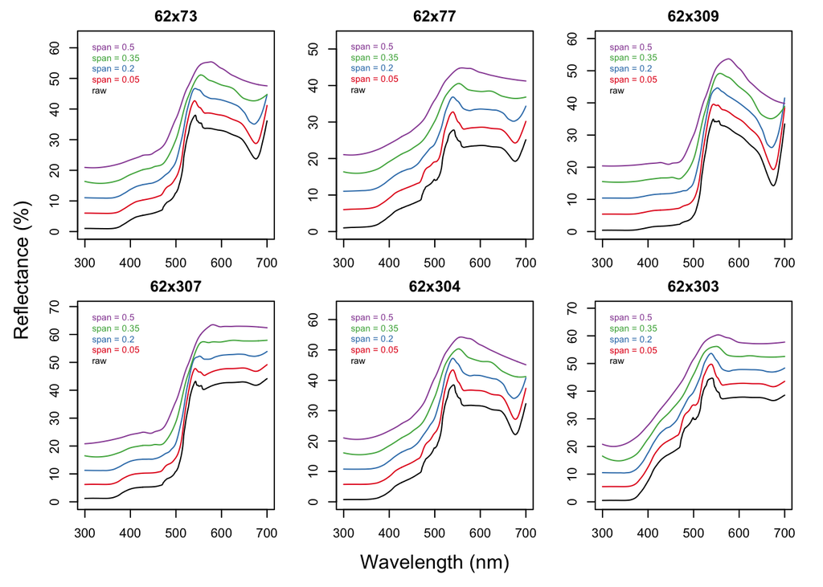

```r
# Plot to determine suitable smoothing span
plotsmooth(bract_spec_avg[,1:7],
           minsmooth = 0.05,
           maxsmooth = 0.5,
           curves = 4,
           ask = FALSE)
```

Choose a span (e.g., 0.2) based on the plot to balance smoothness and data fidelity.

## 4.6 Smooth the Spectral Data

Apply smoothing to the spectral data using the chosen span.

```r
# Apply smoothing with span = 0.2
bract_spec_sm <- procspec(bract_spec_avg, opt = "smooth", span = 0.2)
```

```
## processing options applied:
## smoothing spectra with a span of 0.2
```

```r
petal_spec_sm <- procspec(petal_spec_avg, opt = "smooth", span = 0.2)
```

```
## processing options applied:
## smoothing spectra with a span of 0.2
```

```r
labellum_spec_sm <- procspec(labellum_spec_avg, opt = "smooth", span = 0.2)
```

```
## processing options applied:
## smoothing spectra with a span of 0.2
```

## 4.7 Scale the Spectral Data

```r
# Scale spectra to both minimum and maximum reflectance
#bract_spec_scalemax <- procspec(bract_spec_sm, opt = c("max"))
#petal_spec_scalemax <- procspec(petal_spec_sm, opt = c("max"))
#labellum_spec_scalemax <- procspec(labellum_spec_sm, opt = c("max"))

bract_spec_scalemax <- bract_spec_sm
petal_spec_scalemax <- petal_spec_sm
labellum_spec_scalemax <- labellum_spec_sm
```

## 4.8 Plot Processed Spectra

Visualize the processed spectral data for each floral tissue, highlighting specific samples.

## 4.9 Define Common Plotting Parameters

```r
# duplicate the spectral data specifically for plotting
bract_spec_plotting <- bract_spec_scalemax
petal_spec_plotting <- petal_spec_scalemax
labellum_spec_plotting <- labellum_spec_scalemax

# Duplicate the parental columns
bract_spec_plotting$`125.2` <- unlist(bract_spec_plotting[which(names(bract_spec_plotting) == "125")])
bract_spec_plotting$`126.2` <- unlist(bract_spec_plotting[which(names(bract_spec_plotting) == "126")])
bract_spec_plotting$BRAC.2 <- unlist(bract_spec_plotting[which(names(bract_spec_plotting) == "BRAC")])

petal_spec_plotting$`125.2` <- unlist(petal_spec_plotting[which(names(petal_spec_plotting) == "125")])
petal_spec_plotting$`126.2` <- unlist(petal_spec_plotting[which(names(petal_spec_plotting) == "126")])
petal_spec_plotting$BRAC.2 <- unlist(petal_spec_plotting[which(names(petal_spec_plotting) == "BRAC")])

labellum_spec_plotting$`125.2` <- unlist(labellum_spec_plotting[which(names(labellum_spec_plotting) == "125")])
labellum_spec_plotting$`126.2` <- unlist(labellum_spec_plotting[which(names(labellum_spec_plotting) == "126")])
labellum_spec_plotting$BRAC.2 <- unlist(labellum_spec_plotting[which(names(labellum_spec_plotting) == "BRAC")])

# Define a color palette for highlighting specific samples
colors_bract <- spec2rgb(bract_spec_plotting)
colors_petal <- spec2rgb(petal_spec_plotting)
colors_labellum <- spec2rgb(labellum_spec_plotting)

# Change the colors of the duplicated parentals
colors_bract[which(names(colors_bract) == "125.2")] <- "black"
colors_bract[which(names(colors_bract) == "126.2")] <- "black"
colors_bract[which(names(colors_bract) == "BRAC.2")] <- "red"

colors_petal[which(names(colors_petal) == "125.2")] <- "black"
colors_petal[which(names(colors_petal) == "126.2")] <- "black"
colors_petal[which(names(colors_petal) == "BRAC.2")] <- "red"

colors_labellum[which(names(colors_labellum) == "125.2")] <- "black"
colors_labellum[which(names(colors_labellum) == "126.2")] <- "black"
colors_labellum[which(names(colors_labellum) == "BRAC.2")] <- "red"
```

## 4.10 Bract Spectra Plot

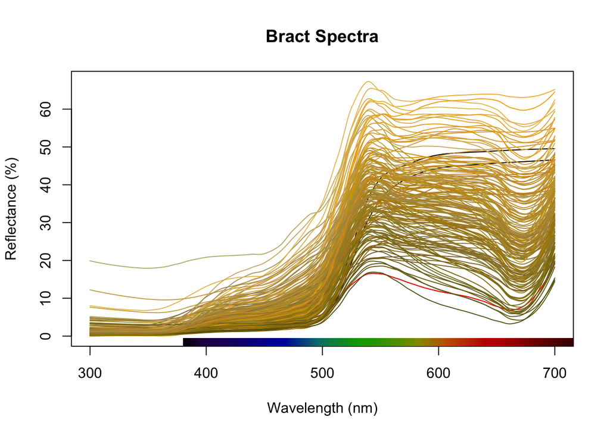

```r
# Order samples to highlight specific ones
order_spec_bract <- c(
  which(names(bract_spec_plotting) == "125"),
  which(names(bract_spec_plotting) == "126"),
  which(names(bract_spec_plotting) == "BRAC"),
  which(names(bract_spec_plotting) == "125.2"),
  which(names(bract_spec_plotting) == "126.2"),
  which(names(bract_spec_plotting) == "BRAC.2")
)

order_spec_bract_col <- c(
  which(names(colors_bract) == "125"),
  which(names(colors_bract) == "126"),
  which(names(colors_bract) == "BRAC"),
  which(names(colors_bract) == "125.2"),
  which(names(colors_bract) == "126.2"),
  which(names(colors_bract) == "BRAC.2")
)

# Reorder columns to place highlighted samples at the beginning
columns_bract <- 1:ncol(bract_spec_plotting)
order_spec_bract <- c(order_spec_bract, columns_bract[columns_bract %notin% order_spec_bract])

columns_bract_color <- 1:length(colors_bract)
order_spec_bract_col <- c(order_spec_bract_col, columns_bract_color[columns_bract_color %notin% order_spec_bract_col])

# Plot
plot(bract_spec_plotting[order_spec_bract],
     type = "o",
     col = colors_bract[order_spec_bract_col],
     main = "Bract Spectra",
     xlab = "Wavelength (nm)",
     ylab = "Reflectance (%)")
```

## 4.11 Petal Spectra Plot

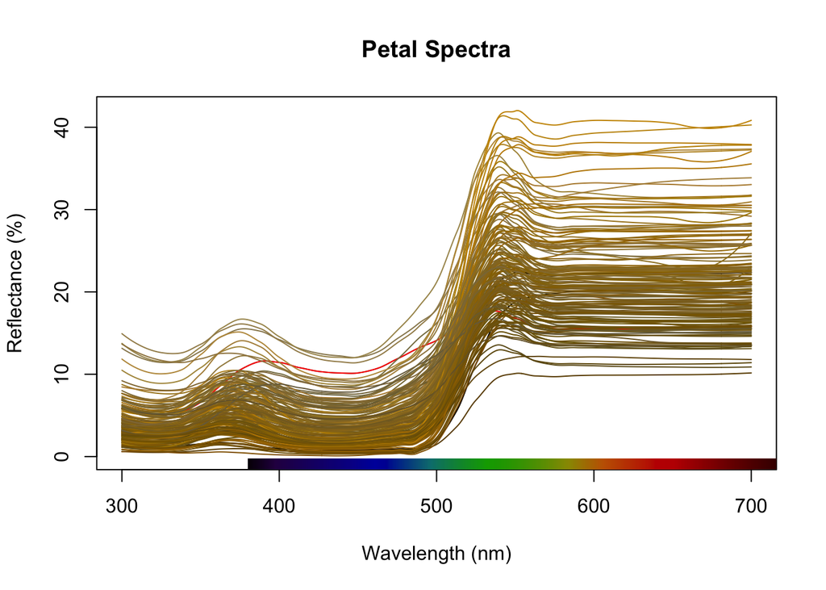

```r
# Order samples to highlight specific ones
order_spec_petal <- c(
  which(names(petal_spec_plotting) == "125"),
  which(names(petal_spec_plotting) == "126"),
  which(names(petal_spec_plotting) == "BRAC"),
  which(names(petal_spec_plotting) == "125.2"),
  which(names(petal_spec_plotting) == "126.2"),
  which(names(petal_spec_plotting) == "BRAC.2")
)

order_spec_petal_col <- c(
  which(names(colors_petal) == "125"),
  which(names(colors_petal) == "126"),
  which(names(colors_petal) == "BRAC"),
  which(names(colors_petal) == "125.2"),
  which(names(colors_petal) == "126.2"),
  which(names(colors_petal) == "BRAC.2")
)

# Reorder columns to place highlighted samples at the beginning
columns_petal <- 1:ncol(petal_spec_plotting)
order_spec_petal <- c(order_spec_petal, columns_petal[columns_petal %notin% order_spec_petal])

columns_petal_color <- 1:length(colors_petal)
order_spec_petal_col <- c(order_spec_petal_col, columns_petal_color[columns_petal_color %notin% order_spec_petal_col])

# Plot
plot(petal_spec_plotting[order_spec_petal],
     type = "o",
     col = colors_petal[order_spec_petal_col],
     main = "Petal Spectra",
     xlab = "Wavelength (nm)",
     ylab = "Reflectance (%)")
```

## 4.12 Labellum Spectra Plot

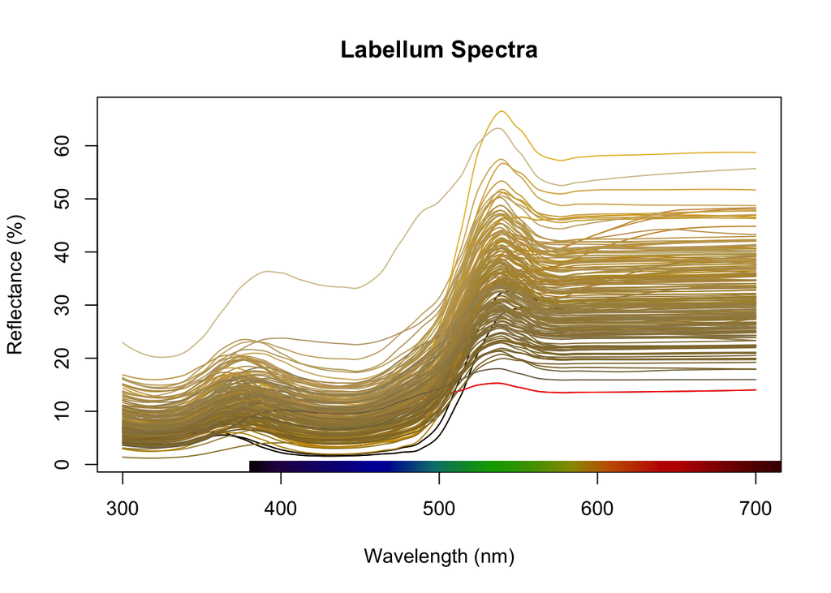

```r
# Order samples to highlight specific ones
order_spec_labellum <- c(
  which(names(labellum_spec_plotting) == "125"),
  which(names(labellum_spec_plotting) == "126"),
  which(names(labellum_spec_plotting) == "BRAC"),
  which(names(labellum_spec_plotting) == "125.2"),
  which(names(labellum_spec_plotting) == "126.2"),
  which(names(labellum_spec_plotting) == "BRAC.2")
)

order_spec_labellum_col <- c(
  which(names(colors_labellum) == "125"),
  which(names(colors_labellum) == "126"),
  which(names(colors_labellum) == "BRAC"),
  which(names(colors_labellum) == "125.2"),
  which(names(colors_labellum) == "126.2"),
  which(names(colors_labellum) == "BRAC.2")
)

# Reorder columns to place highlighted samples at the beginning
columns_labellum <- 1:ncol(labellum_spec_plotting)
order_spec_labellum <- c(order_spec_labellum, columns_labellum[columns_labellum %notin% order_spec_labellum])

columns_labellum_color <- 1:length(colors_labellum)
order_spec_labellum_col <- c(order_spec_labellum_col, columns_labellum_color[columns_labellum_color %notin% order_spec_labellum_col])

# Plot
plot(labellum_spec_plotting[order_spec_labellum],
     type = "o",
     col = colors_labellum[order_spec_labellum_col],
     main = "Labellum Spectra",
     xlab = "Wavelength (nm)",
     ylab = "Reflectance (%)")
```

## 4.13 Combine and Save Spectral Plots with Highlighted Parents

```r
# Save combined spectra plots with highlighted parental samples
pdf("~/Dropbox/Costus/costus-genetic-mapping/phenotype/results/figures/Combined_Spectra_Bract_Petal_Labellum_Cbracteatus_Clasius_hybrids_alternate.pdf", width = 25, height = 7)
par(mfrow = c(1, 3))
# Increase left margin to provide more space for y-axis labels
par(mar = c(5, 5, 4, 2) + 0.1)  # c(bottom, left, top, right)
plot(bract_spec_plotting[order_spec_bract],
     type = "o",
     col = colors_bract[order_spec_bract_col],
     main = "Bract Spectra",
     xlab = "Wavelength (nm)",
     ylab = "Reflectance (%)",
     cex.main = 2.5,
     cex.lab = 2.5,
     cex.axis = 2.5)
plot(petal_spec_plotting[order_spec_petal],
     type = "o",
     col = colors_petal[order_spec_petal_col],
     main = "Petal Spectra",
     xlab = "Wavelength (nm)",
     ylab = "Reflectance (%)",
     cex.main = 2.5,
     cex.lab = 2.5,
     cex.axis = 2.5)
plot(labellum_spec_plotting[order_spec_labellum],
     type = "o",
     col = colors_labellum[order_spec_labellum_col],
     main = "Labellum Spectra",
     xlab = "Wavelength (nm)",
     ylab = "Reflectance (%)",
     cex.main = 2.5,
     cex.lab = 2.5,
     cex.axis = 2.5)
dev.off()
```